# Reproducible Research: Peer Assessment 1

## Are there differences in activity patterns between weekdays and weekends?

```r
daily_corrected <- data_clone %>%
        group_by(as.Date(date)) %>%
        summarise(total = sum(as.numeric(steps), na.rm = TRUE))
names(daily_corrected)[1] <- "date"
daily_corrected$day <- weekdays(daily_corrected$date)
daily_corrected <- daily_corrected[-1,]
weekdays <- subset(daily_corrected, day == "Monday" |
                           day == "Tuesday" |
                           day == "Wednesday" |
                           day == "Thursday" |
                           day == "Friday")
weekends <- subset(daily_corrected, day == "Saturday" |
                           day == "Sunday")
mean_weekdays <- weekdays %>%
        group_by(day) %>%
        summarise(mean_steps = mean(total, na.rm = TRUE))
mean_weekends <- weekends %>%
        group_by(day) %>%
        summarise(mean_steps = mean(total, na.rm = TRUE))
```

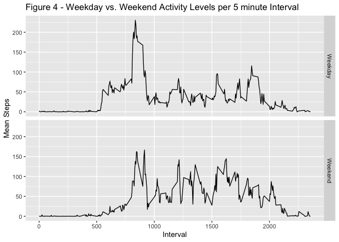

```r
data_clone$weekday <- weekdays(data_clone$date)
data_clone$type_of_day <- sapply(data_clone$weekday, function(x) {
                if(x == "Monday" | x == "Tuesday" | x == "Wednesday" | x == "Thursday" | x == "Friday") {return("Weekday")}
                else {return("Weekend")}
})

type_of_day_summary <- data_clone %>%
        group_by(type_of_day, interval) %>%
        summarise(mean_steps = mean(as.numeric(steps), na.rm = TRUE))

require(ggplot2)
qplot(interval, mean_steps, data = type_of_day_summary, facets = type_of_day~., geom = "line", xlab = "Interval", ylab = "Mean Steps", main = "Figure 4 - Weekday vs. Weekend Activity Levels per 5 minute Interval ")
```

**Figure 4** shows the difference in the mean number of steps over the course of 24 hours for this dataset. Weekday activity seems to be more pronounced between 7:30 am and 10:am, perhaps correlating with commute time. General activity during waking hours over the weekend however, seems to be higher.

The activity patterns for Monday to Sunday over this period can be seen below in **Figure 5.**

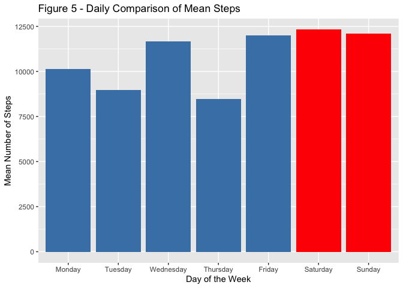

```r
all_week <- rbind(mean_weekdays, mean_weekends)
DOW <- c("Monday", "Tuesday", "Wednesday", "Thursday", "Friday", "Saturday", "Sunday")
all_week$day <- factor(all_week$day, levels = DOW)
all_week <- all_week[order(all_week$day),]

require(ggplot2)
colours <- c(rep("steelblue",5), rep("red",2))
g <- ggplot(data = all_week, aes(x = day, y = mean_steps)) + geom_col(fill = colours)
g <- g + xlab("Day of the Week")
g <- g + ylab("Mean Number of Steps")
g <- g + labs(title = "Figure 5 - Daily Comparison of Mean Steps")
show(g)
```

Both days of the weekend have higher mean activity levels compared to weekdays. There appears to be a significant decline in activity on a Tuesday and Thursday. This may suggest that the user is more active on a weekend, although other causes, such as consistent use during the week, would need to be ruled out first.

**Figure 6** shows the dispersion for the data in question.

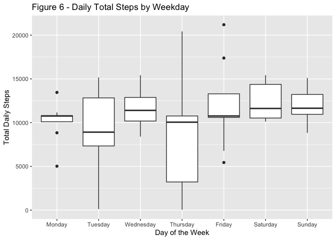

```r
weekdays_weekends <- rbind(weekdays, weekends)
weekdays_weekends$day <- factor(weekdays_weekends$day, levels = DOW)
weekdays_weekends <- weekdays_weekends[order(weekdays_weekends$day),]

p <- ggplot(weekdays_weekends, aes(x = day, y = total)) + geom_boxplot()
p <- p + xlab("Day of the Week") + ylab("Total Daily Steps")
p <- p + labs(title = "Figure 6 - Daily Total Steps by Weekday")
show(p)
```

Upon further inspection, the median step count and inter-quartile range appear to be generally consistent in the data from Wednesdays, Fridays, Saturdays and Sundays. Data from Tuesday and Thursday features a significant proportion of low step counts and the cause of this would need to be investigated further before making declarative conclusions about weekday versus weekend activity levels for this individual.